# 542: Week 1 - R Review & Intro to RMarkdown

Fred Traylor, Lab TA

1/24/2022

Clicking the grey triangle with the green bar under it, next to the green triangle, will run every code chunk that comes before this one.

These two functions can make it easy to run and rerun large segments of code without having to highlight them specifically.

To insert your own chunk, click on the green square with a C inside in, on the top right of this pane, or type `CTRL + ALT + I`.

For this class, we’ll be using RMarkdown for the homework assignments, so we want to see the code that we use. Click that gear and tell it to “Show code and output” or simply change the `echo=FALSE` to `echo=TRUE` in the chunk’s header.

## So what is R Markdown?

You can also click the drop-down arrow next to Knit and select to knit it as a PDF or as a Word Document. This requires some more software to be added in, so we’ll wait a little later to do that.

### Find the Working Directory

To find out where your code is being stored, run the `getwd()` command in the below chunk.

```r
getwd()
```

```
## [1] "/Users/jasonarchimandritis/Downloads"
```

If your project is not somewhere permanent, move it now and rerun the above chunk to verify the location.

### R Script vs RMarkdown

Last semester, we used R Script (aka .R files) to do our work. This semester, we’ll be using RMarkdown (aka .Rmd files). R Script is great for running analysis, but deprioritizes text. (Remember how we’d have to comment out any notes we had?)

RMarkdown works the opposite: Text is its primary function, and you have to tell it when to run code. This is great for reports where you want to add your analysis, results, and graphs without having to copy and paste.

## R Basics Review

### Data Management with the tidyverse

We’re going to use the `gapminder` package to load up our data. The Gapminder project has data on a wide variety of indicators, for most countries of the world, and for many decades. This provides a great opportunity for us to analyze development. For now, though, we’ll just use a small subset of data. Run the below chunk to see what we’re working with.

```r
if(!require(gapminder))          # If gapminder package isn't intalled...
  install.packages("gapminder")  # ... Install it
minded <- gapminder::gapminder
names(minded)
```

```
## [1] "country"   "continent" "year"      "lifeExp"   "pop"       "gdpPercap"
```

With that loaded up, let’s do a little bit of data management.

```r
minded %>%   # Make sure you run the very first code chunk (lines 8-11) to load the tidyverse
  mutate(
    shortyear = year - 1950,             # Starting years at 1950
    recent = case_when(
      year > 2000 ~ "Post 2000",
      TRUE ~ "Pre 2000"                  # TRUE means "everything else"
      ),
    newyears = case_when(
      year %in% c(1997, 2002, 2007) ~ 1, # We can use this way to select recent years, too
      TRUE ~ 0
      )
    ) %>%
  select(year, shortyear, recent, newyears)  # select(columns)
```

```
## # A tibble: 1,704 × 4
##     year shortyear recent   newyears
##    <int>     <dbl> <chr>       <dbl>
##  1  1952         2 Pre 2000        0
##  2  1957         7 Pre 2000        0
##  3  1962        12 Pre 2000        0
##  4  1967        17 Pre 2000        0
##  5  1972        22 Pre 2000        0
##  6  1977        27 Pre 2000        0
##  7  1982        32 Pre 2000        0
##  8  1987        37 Pre 2000        0
##  9  1992        42 Pre 2000        0
## 10  1997        47 Pre 2000        1
## # … with 1,694 more rows
```

```r
newminder <- minded %>%            # Create new dataset
  rename(gdp_cap = gdpPercap) %>%  # rename(newname = oldname)
  select(year, gdp_cap) %>%
  filter(gdp_cap < 1000)           # only include rows where gdp_gap is less than 1000
newminder
```

```
## # A tibble: 351 × 2
##     year gdp_cap
##    <int>   <dbl>
##  1  1952    779.
##  2  1957    821.
##  3  1962    853.
##  4  1967    836.
##  5  1972    740.
##  6  1977    786.
##  7  1982    978.
##  8  1987    852.
##  9  1992    649.
## 10  1997    635.
## # … with 341 more rows
```

Also notice that, above each of these outputs, it shows the type of data (in this case tibbles) and the dimensions.

### Graphing with `ggplot2`

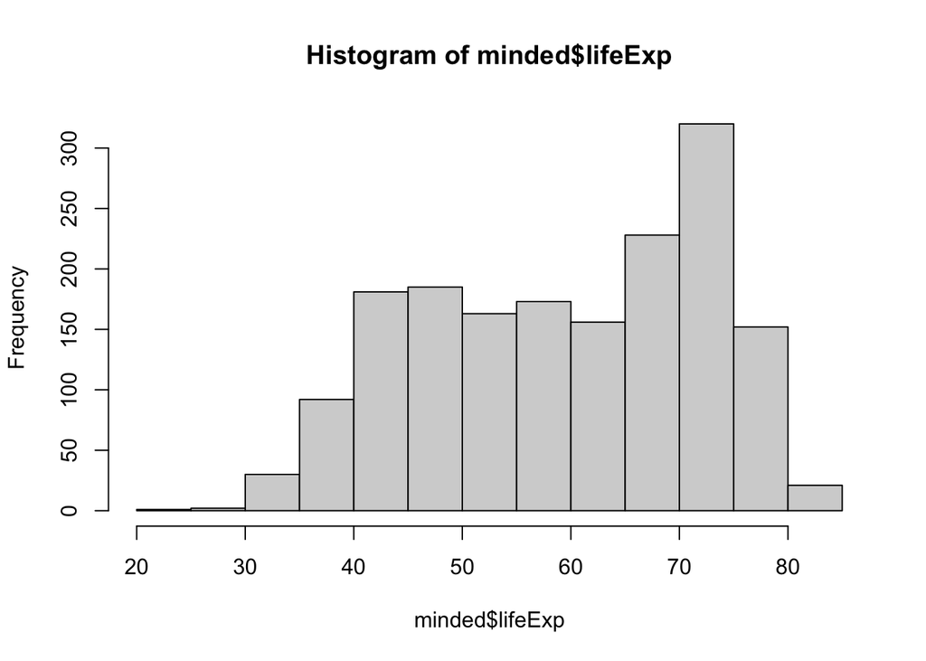

```r
hist(minded$lifeExp)
```

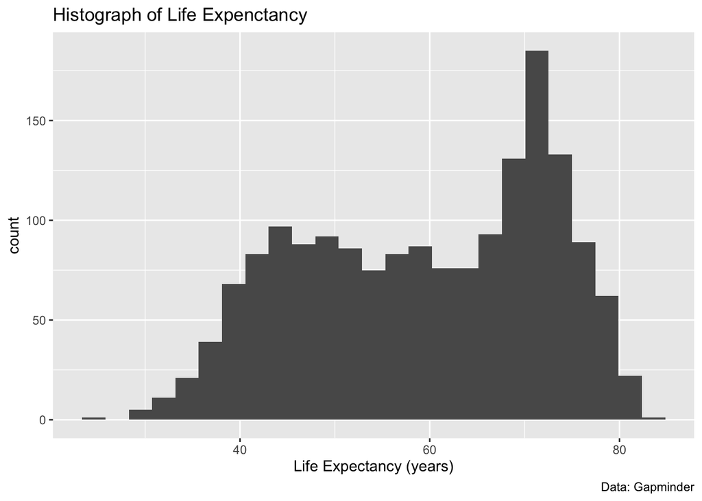

```r
minded %>%
  ggplot(aes(x = lifeExp)) +
  geom_histogram(bins = 25) +
  labs(title = "Histograph of Life Expenctancy",
       caption = "Data: Gapminder",
       x = "Life Expectancy (years)")
```

Here is another example of a graph, this time with two variables. I also changed the color of the dots based on continents.

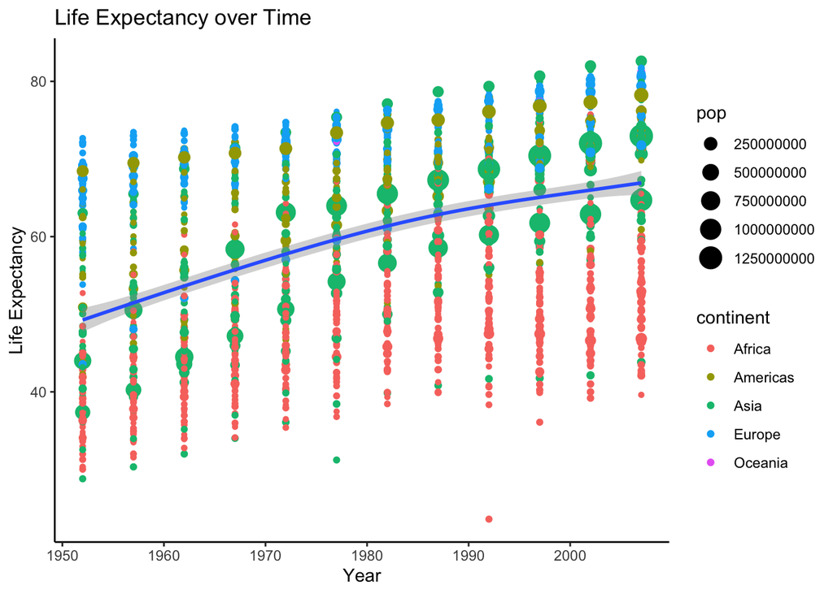

```r
minded %>%
  ggplot(aes(x = year,
             y = lifeExp)) +
  geom_point(aes(color = continent,
                 size = pop)) +
  geom_smooth() +
  theme_classic() +
  labs(title = "Life Expectancy over Time",
       x = "Year",
       y = "Life Expectancy")
```

## Working With Git and GitHub

Git is a type of “version control” system. If you’ve ever saved a file and later wished you could go back to a previous version, Git is for you!

GitHub, then, is a place to store our code and all its previous versions. And like R, it’s free.

We’ll now walk through the process of installing Git and linking our Github to our RStudio project. The best resource for this is Jenny Bryan’s Happy Git with R: https://happygitwithr.com/index.html

Chapters 4, 6, 7, 9-13, and 17 are the key sections here. We’re going to start this together, and continue one-on-one this week.